# PaperRush Feature Inventory EDA: Weeklies vs SIP

PaperRush analysis

2026-05-11

# 1 Scope

This notebook intentionally reads only the historical training files directly under /Users/norbert.jaworski/Documents/uni/2 rok/understandingBusiness/project/input. It does not read /Users/norbert.jaworski/Documents/uni/2 rok/understandingBusiness/project/input/Printing Schedule (On Sale July 2024), which is the July 2024 holdout folder.

The analysis grain is one historical `STORE_ID x PRODUCT_ID` fact row after joining product, store, and optionally demographic attributes. Tables are grouped by `TYPE`, with the practical focus on `Weeklies` and `SIP`.

```r
paths <- list(
  fact = file.path(historical_input_dir, "FACT_TABLE.csv"),
  product = file.path(historical_input_dir, "DIM_PRODUCT.csv"),
  store = file.path(historical_input_dir, "DIM_STORE.csv"),
  demographics = file.path(historical_input_dir, "DEMOGRAPHICS.csv")
)

path_audit <- data.table(
  source = names(paths),
  path = unlist(paths, use.names = FALSE),
  exists = file.exists(unlist(paths, use.names = FALSE))
)
path_audit[, july_holdout_path := grepl("Printing Schedule \\(On Sale July 2024\\)", path)]
write_output(path_audit, "path_audit")
display_table(path_audit, "Historical input paths used by this EDA")
```

| source | path | exists | july_holdout_path |
| --- | --- | --- | --- |
| fact | /Users/norbert.jaworski/Documents/uni/2 rok/understandingBusiness/project/input/FACT_TABLE.csv | True | False |
| product | /Users/norbert.jaworski/Documents/uni/2 rok/understandingBusiness/project/input/DIM_PRODUCT.csv | True | False |
| store | /Users/norbert.jaworski/Documents/uni/2 rok/understandingBusiness/project/input/DIM_STORE.csv | True | False |
| demographics | /Users/norbert.jaworski/Documents/uni/2 rok/understandingBusiness/project/input/DEMOGRAPHICS.csv | True | False |

# 2 Load And Join Data

```r
fact <- fread(paths$fact, showProgress = TRUE) |> normalize_names()
product <- fread(paths$product, showProgress = TRUE) |> normalize_names()
store <- fread(paths$store, showProgress = TRUE) |> normalize_names()

demographics <- NULL
if (isTRUE(params$include_demographics) && file.exists(paths$demographics)) {
  demographics <- fread(paths$demographics, showProgress = TRUE) |> normalize_names()
}

coerce_numeric(fact, c("store_id", "product_id", "soldqty", "drawqty"))
coerce_numeric(product, c("product_id", "price"))
coerce_numeric(store, c("store_id", "facings", "pockets"))

product[, `:=`(
  barcode = clean_character(barcode),
  title = clean_character(title),
  type = clean_character(type),
  segment = clean_character(segment),
  subsegment = clean_character(subsegment),
  frequency = clean_character(frequency),
  onsaledate = as.IDate(onsaledate),
  offsaledate = as.IDate(offsaledate)
)]

store[, `:=`(
  postal_code = clean_character(postal_code),
  store_chain = clean_character(store_chain),
  region = clean_character(region),
  classoftrade = clean_character(classoftrade),
  merchandised = clean_boolish(merchandised)
)]

if (!is.null(demographics)) {
  demographics[, postal_code := clean_character(postal_code)]
  demographic_numeric_cols <- setdiff(names(demographics), "postal_code")
  coerce_numeric(demographics, demographic_numeric_cols)

  demographics <- demographics[
    ,
    lapply(.SD, function(x) {
      if (is.numeric(x)) {
        if (all(is.na(x))) NA_real_ else max(x, na.rm = TRUE)
      } else {
        x[which.max(!is.na(x))]
      }
    }),
    by = postal_code
  ]
}

setkey(product, product_id)
setkey(store, store_id)
setkey(fact, product_id)
analysis <- product[fact, nomatch = 0]
setkey(analysis, store_id)
analysis <- store[analysis, nomatch = 0]

if (!is.null(demographics)) {
  setkey(demographics, postal_code)
  setkey(analysis, postal_code)
  analysis <- demographics[analysis]
}

analysis[, `:=`(
  type = fifelse(is.na(type), "UNKNOWN", type),
  issue_length_days = as.numeric(offsaledate - onsaledate),
  onsale_month = as.integer(format(onsaledate, "%m")),
  onsale_week = as.integer(strftime(onsaledate, format = "%V")),
  sellthrough = fifelse(drawqty > 0, soldqty / drawqty, NA_real_),
  oversupply_units = pmax(drawqty - pmax(soldqty, 0), 0),
  stockout_proxy_flag = drawqty > 0 & soldqty == drawqty,
  negative_soldqty_flag = soldqty < 0,
  zero_soldqty_flag = soldqty == 0
)]

target_types <- c("Weeklies", "SIP")
analysis <- analysis[type %in% target_types]
analysis[, type := factor(type, levels = target_types)]
```

```r
data_audit <- rbindlist(list(
  data.table(table = "FACT_TABLE", rows = nrow(fact), columns = ncol(fact)),
  data.table(table = "DIM_PRODUCT", rows = nrow(product), columns = ncol(product)),
  data.table(table = "DIM_STORE", rows = nrow(store), columns = ncol(store)),
  data.table(table = "DEMOGRAPHICS", rows = ifelse(is.null(demographics), 0L, nrow(demographics)), columns = ifelse(is.null(demographics), 0L, ncol(demographics))),
  data.table(table = "ANALYSIS_PANEL_WEEKLIES_SIP", rows = nrow(analysis), columns = ncol(analysis))
))

type_overview <- analysis[
  ,
  .(
    fact_rows = .N,
    stores = uniqueN(store_id),
    products = uniqueN(product_id),
    titles = uniqueN(title, na.rm = TRUE),
    segments = uniqueN(segment, na.rm = TRUE),
    subsegments = uniqueN(subsegment, na.rm = TRUE),
    first_onsale = min(onsaledate, na.rm = TRUE),
    last_onsale = max(onsaledate, na.rm = TRUE),
    soldqty_sum = sum(soldqty, na.rm = TRUE),
    drawqty_sum = sum(drawqty, na.rm = TRUE),
    aggregate_sellthrough = sum(soldqty, na.rm = TRUE) / sum(drawqty, na.rm = TRUE),
    row_avg_sellthrough = mean(sellthrough, na.rm = TRUE),
    zero_sales_rate = mean(zero_soldqty_flag, na.rm = TRUE),
    negative_sales_rate = mean(negative_soldqty_flag, na.rm = TRUE),
    stockout_proxy_rate = mean(stockout_proxy_flag, na.rm = TRUE)
  ),
  by = type
]

write_output(data_audit, "data_audit")
write_output(type_overview, "type_overview")

display_table(data_audit, "Loaded data audit")
```

| table | rows | columns |
| --- | --- | --- |
| FACT_TABLE | 16590626 | 4 |
| DIM_PRODUCT | 5324 | 10 |
| DIM_STORE | 29622 | 8 |
| DEMOGRAPHICS | 7387 | 33 |
| ANALYSIS_PANEL_WEEKLIES_SIP | 16590626 | 60 |

```r
display_table(type_overview, "Weeklies vs SIP row-grain overview")
```

| type | fact_rows | stores | products | titles | segments | subsegments | first_onsale | last_onsale | soldqty_sum | drawqty_sum | aggregate_sellthrough | row_avg_sellthrough | zero_sales_rate | negative_sales_rate | stockout_proxy_rate |
| --- | --- | --- | --- | --- | --- | --- | --- | --- | --- | --- | --- | --- | --- | --- | --- |
| SIP | 10890176 | 29596 | 3236 | 1 | 17 | 53 | 2023-01-02 | 2024-06-03 | 4989173 | 38694187 | 0.1289385664053363 | 0.1109490587597232 | 0.7692190649627701 | 0.0007009987717370225 | 0.0248751718980483 |
| Weeklies | 5700450 | 28518 | 2088 | 6 | 2 | 3 | 2023-01-02 | 2024-06-24 | 8312665 | 46240829 | 0.1797689440213107 | 0.1379461868674715 | 0.6378080677841224 | 0.0007166100921857046 | 0.02327114526046189 |

# 3 Feature Lists

```r
base_categorical_features <- c(
  "title",
  "barcode",
  "segment",
  "subsegment",
  "frequency",
  "store_chain",
  "region",
  "classoftrade",
  "merchandised",
  "postal_code"
)

engineered_categorical_features <- c(
  "onsale_month",
  "onsale_week"
)

base_numeric_features <- c(
  "soldqty",
  "drawqty",
  "sellthrough",
  "oversupply_units",
  "price",
  "issue_length_days",
  "facings",
  "pockets"
)

demographic_numeric_features <- if (!is.null(demographics)) {
  setdiff(names(demographics), "postal_code")
} else {
  character(0)
}

categorical_features <- intersect(
  c(base_categorical_features, engineered_categorical_features),
  names(analysis)
)

numeric_features <- intersect(
  c(base_numeric_features, demographic_numeric_features),
  names(analysis)
)

feature_inventory <- data.table(
  feature = c(categorical_features, numeric_features),
  feature_role = c(rep("categorical", length(categorical_features)), rep("numeric", length(numeric_features)))
)

write_output(feature_inventory, "feature_inventory")
display_table(feature_inventory, "Features profiled in this notebook")
```

| feature | feature_role |
| --- | --- |
| title | categorical |
| barcode | categorical |
| segment | categorical |
| subsegment | categorical |
| frequency | categorical |
| store_chain | categorical |
| region | categorical |
| classoftrade | categorical |
| merchandised | categorical |
| postal_code | categorical |

[output cut: 42 more lines]

# 4 Categorical Values

The table in this section is the full inventory of categorical values by product type and feature. It is also written to `categorical_value_inventory.csv` in the output directory.

```r
categorical_summary_one <- function(dt, feature) {
  value <- as.character(dt[[feature]])
  value[is.na(value) | trimws(value) == ""] <- "(missing)"
  tmp <- data.table(
    type = dt$type,
    feature = feature,
    value = value,
    product_id = dt$product_id,
    store_id = dt$store_id,
    soldqty = dt$soldqty,
    drawqty = dt$drawqty,
    sellthrough = dt$sellthrough,
    zero_soldqty_flag = dt$zero_soldqty_flag,
    stockout_proxy_flag = dt$stockout_proxy_flag
  )

  tmp[
    ,
    .(
      row_count = .N,
      row_share_within_type_feature = .N / .N,
      product_count = uniqueN(product_id),
      store_count = uniqueN(store_id),
      soldqty_sum = sum(soldqty, na.rm = TRUE),
      drawqty_sum = sum(drawqty, na.rm = TRUE),
      aggregate_sellthrough = sum(soldqty, na.rm = TRUE) / sum(drawqty, na.rm = TRUE),
      row_avg_sellthrough = mean(sellthrough, na.rm = TRUE),
      zero_sales_rate = mean(zero_soldqty_flag, na.rm = TRUE),
      stockout_proxy_rate = mean(stockout_proxy_flag, na.rm = TRUE)
    ),
    by = .(type, feature, value)
  ][
    ,
    row_share_within_type_feature := row_count / sum(row_count),
    by = .(type, feature)
  ][order(type, feature, -row_count, value)]
}

categorical_value_inventory <- rbindlist(
  lapply(categorical_features, function(feature) categorical_summary_one(analysis, feature)),
  use.names = TRUE,
  fill = TRUE
)

categorical_cardinality <- categorical_value_inventory[
  ,
  .(
    distinct_values = .N,
    missing_values_present = any(value == "(missing)"),
    largest_value_row_share = max(row_share_within_type_feature, na.rm = TRUE),
    top_value = value[which.max(row_count)]
  ),
  by = .(type, feature)
][order(type, -distinct_values)]

write_output(categorical_cardinality, "categorical_cardinality")
write_output(categorical_value_inventory, "categorical_value_inventory")

display_table(categorical_cardinality, "Categorical feature cardinality by Weeklies and SIP")
```

| type | feature | distinct_values | missing_values_present | largest_value_row_share | top_value |
| --- | --- | --- | --- | --- | --- |
| Weeklies | postal_code | 7602 | False | 0.0007873062652948451 | 31-580 |
| Weeklies | store_chain | 101 | False | 0.1719727389942899 | Chain 6 |
| Weeklies | onsale_week | 52 | False | 0.03130945802524362 | 20 |
| Weeklies | barcode | 17 | False | 0.1221580752396741 | 64449 |
| Weeklies | classoftrade | 17 | False | 0.3716648685630082 | SM CHAIN |
| Weeklies | region | 16 | False | 0.1839760018945873 | Lublin |
| Weeklies | onsale_month | 12 | False | 0.1296057328807375 | 4 |
| Weeklies | title | 6 | False | 0.2434618319606347 | Simply Woman |
| Weeklies | subsegment | 3 | False | 0.572044312291135 | CELEBRITY PROFILE |
| Weeklies | frequency | 3 | False | 0.5680716434667439 | Bi-Weekly - 26 Issues |

[output cut: 14 more lines]

```r
display_table(categorical_value_inventory, "Full categorical value inventory by Weeklies and SIP")
```

| type | feature | value | row_count | row_share_within_type_feature | product_count | store_count | soldqty_sum | drawqty_sum | aggregate_sellthrough | row_avg_sellthrough | zero_sales_rate | stockout_proxy_rate |
| --- | --- | --- | --- | --- | --- | --- | --- | --- | --- | --- | --- | --- |
| Weeklies | title | Simply Woman | 1387842 | 0.2434618319606347 | 348 | 27649 | 4578959 | 22358709 | 0.2047953215903476 | 0.1784145942962829 | 0.4763633036037244 | 0.02328435081226825 |
| Weeklies | title | Spotlight Lives | 1094852 | 0.192064135287565 | 385 | 26432 | 711641 | 4575570 | 0.1555305677762552 | 0.1300556436563493 | 0.6955506315008787 | 0.02632684600293008 |
| Weeklies | title | Fame &amp; Faces | 1006485 | 0.1765623766544746 | 402 | 25616 | 654356 | 5963967 | 0.1097182462612553 | 0.09985286855993203 | 0.7105023919879581 | 0.01674242537146604 |
| Weeklies | title | Starline Stories | 781042 | 0.137014095378435 | 353 | 21624 | 339796 | 2290597 | 0.1483438597012045 | 0.1226320237658127 | 0.7577671879361161 | 0.02751580580813836 |
| Weeklies | title | Echo of Fame | 731332 | 0.1282937311966599 | 312 | 17441 | 383764 | 2697721 | 0.1422548884780895 | 0.1180787950182392 | 0.7286471807605848 | 0.0188587399430081 |
| Weeklies | title | Everyday Bloom | 698897 | 0.1226038295222307 | 288 | 28355 | 1644149 | 8354265 | 0.1968035488460086 | 0.1627371580636412 | 0.5341416546358047 | 0.02773370038789693 |
| SIP | title | Title SIP | 10890176 | 1 | 3236 | 29596 | 4989173 | 38694187 | 0.1289385664053363 | 0.1109490587597232 | 0.7692190649627701 | 0.0248751718980483 |
| Weeklies | barcode | 64449 | 696356 | 0.1221580752396741 | 156 | 24920 | 2288656 | 11322357 | 0.2021360040140052 | 0.1765752778710934 | 0.476175978953294 | 0.02364451516178506 |
| Weeklies | barcode | 64803 | 691450 | 0.1212974414300625 | 156 | 24182 | 2290236 | 11035763 | 0.2075285596473937 | 0.1802696800807984 | 0.4765434955528238 | 0.02291705835562947 |
| Weeklies | barcode | 57601 | 550399 | 0.09655360541711619 | 156 | 22096 | 358088 | 2302950 | 0.1554910006730498 | 0.1283546279209581 | 0.6967472687995436 | 0.02660433612706418 |

[output cut: 4990 more lines]

```r
categorical_preview <- categorical_value_inventory[
  ,
  head(.SD, params$top_n_preview),
  by = .(type, feature)
]

display_table(categorical_preview, paste0("Top ", params$top_n_preview, " categorical values per feature and type"))
```

| type | feature | value | row_count | row_share_within_type_feature | product_count | store_count | soldqty_sum | drawqty_sum | aggregate_sellthrough | row_avg_sellthrough | zero_sales_rate | stockout_proxy_rate |
| --- | --- | --- | --- | --- | --- | --- | --- | --- | --- | --- | --- | --- |
| Weeklies | title | Simply Woman | 1387842 | 0.2434618319606347 | 348 | 27649 | 4578959 | 22358709 | 0.2047953215903476 | 0.1784145942962829 | 0.4763633036037244 | 0.02328435081226825 |
| Weeklies | title | Spotlight Lives | 1094852 | 0.192064135287565 | 385 | 26432 | 711641 | 4575570 | 0.1555305677762552 | 0.1300556436563493 | 0.6955506315008787 | 0.02632684600293008 |
| Weeklies | title | Fame &amp; Faces | 1006485 | 0.1765623766544746 | 402 | 25616 | 654356 | 5963967 | 0.1097182462612553 | 0.09985286855993203 | 0.7105023919879581 | 0.01674242537146604 |
| Weeklies | title | Starline Stories | 781042 | 0.137014095378435 | 353 | 21624 | 339796 | 2290597 | 0.1483438597012045 | 0.1226320237658127 | 0.7577671879361161 | 0.02751580580813836 |
| Weeklies | title | Echo of Fame | 731332 | 0.1282937311966599 | 312 | 17441 | 383764 | 2697721 | 0.1422548884780895 | 0.1180787950182392 | 0.7286471807605848 | 0.0188587399430081 |
| Weeklies | title | Everyday Bloom | 698897 | 0.1226038295222307 | 288 | 28355 | 1644149 | 8354265 | 0.1968035488460086 | 0.1627371580636412 | 0.5341416546358047 | 0.02773370038789693 |
| SIP | title | Title SIP | 10890176 | 1 | 3236 | 29596 | 4989173 | 38694187 | 0.1289385664053363 | 0.1109490587597232 | 0.7692190649627701 | 0.0248751718980483 |
| Weeklies | barcode | 64449 | 696356 | 0.1221580752396741 | 156 | 24920 | 2288656 | 11322357 | 0.2021360040140052 | 0.1765752778710934 | 0.476175978953294 | 0.02364451516178506 |
| Weeklies | barcode | 64803 | 691450 | 0.1212974414300625 | 156 | 24182 | 2290236 | 11035763 | 0.2075285596473937 | 0.1802696800807984 | 0.4765434955528238 | 0.02291705835562947 |
| Weeklies | barcode | 57601 | 550399 | 0.09655360541711619 | 156 | 22096 | 358088 | 2302950 | 0.1554910006730498 | 0.1283546279209581 | 0.6967472687995436 | 0.02660433612706418 |

[output cut: 536 more lines]

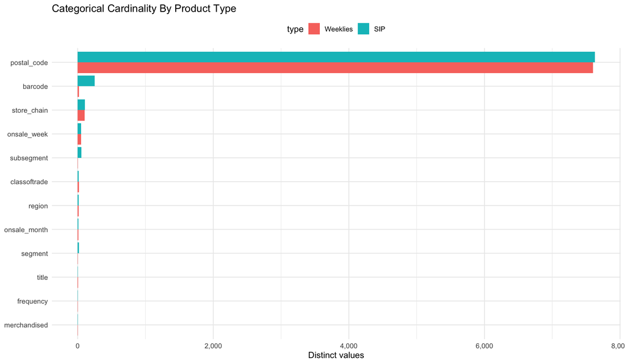

```r
ggplot(categorical_cardinality, aes(x = reorder(feature, distinct_values), y = distinct_values, fill = type)) +
  geom_col(position = "dodge") +
  coord_flip() +
  scale_y_continuous(labels = comma) +
  labs(
    title = "Categorical Cardinality By Product Type",
    x = NULL,
    y = "Distinct values"
  ) +
  theme_minimal(base_size = 12) +
  theme(legend.position = "top")
```

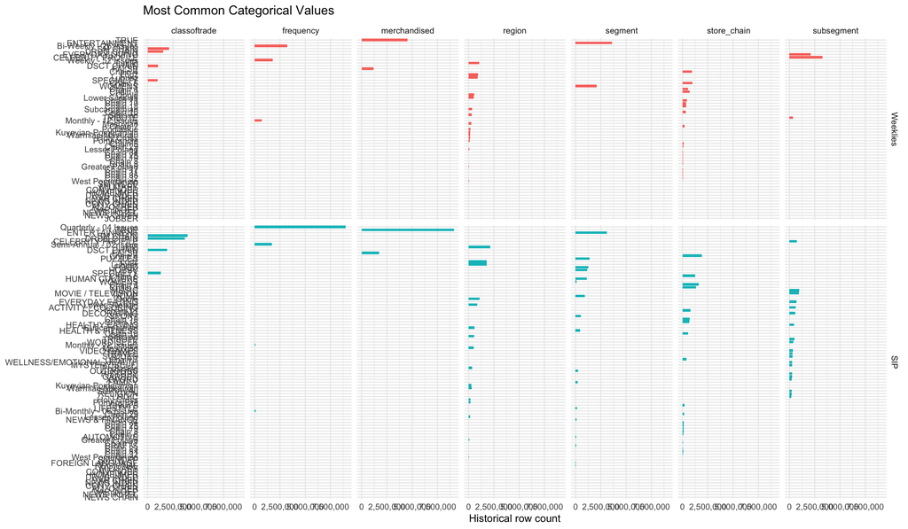

```r
plot_cats <- categorical_value_inventory[
  feature %in% c("segment", "subsegment", "frequency", "store_chain", "region", "classoftrade", "merchandised"),
  head(.SD, params$top_n_plot),
  by = .(type, feature)
]

ggplot(plot_cats, aes(x = reorder(value, row_count), y = row_count, fill = type)) +
  geom_col(show.legend = FALSE) +
  coord_flip() +
  facet_grid(type ~ feature, scales = "free_y", space = "free_y") +
  scale_y_continuous(labels = comma) +
  labs(
    title = "Most Common Categorical Values",
    x = NULL,
    y = "Historical row count"
  ) +
  theme_minimal(base_size = 10)
```

# 5 Numerical Feature Ranges

The main numeric table gives range and distribution statistics separately for Weeklies and SIP. It is also written to `numeric_feature_ranges.csv`.

```r
numeric_summary_one <- function(dt, feature) {
  x <- suppressWarnings(as.numeric(dt[[feature]]))
  data.table(type = dt$type, value = x)[
    ,
    {
      clean <- value[!is.na(value)]
      qs <- if (length(clean) > 0) {
        as.numeric(stats::quantile(clean, probs = c(0.01, 0.05, 0.25, 0.50, 0.75, 0.95, 0.99), na.rm = TRUE, names = FALSE, type = 7))
      } else {
        rep(NA_real_, 7)
      }
      .(
        feature = feature,
        row_count = .N,
        non_missing_count = sum(!is.na(value)),
        missing_count = sum(is.na(value)),
        missing_rate = mean(is.na(value)),
        distinct_values = uniqueN(value, na.rm = TRUE),
        min = ifelse(length(clean) > 0, min(clean), NA_real_),
        p01 = qs[1],
        p05 = qs[2],
        q25 = qs[3],
        median = qs[4],
        mean = ifelse(length(clean) > 0, mean(clean), NA_real_),
        q75 = qs[5],
        p95 = qs[6],
        p99 = qs[7],
        max = ifelse(length(clean) > 0, max(clean), NA_real_),
        sd = ifelse(length(clean) > 1, stats::sd(clean), NA_real_),
        negative_count = sum(value < 0, na.rm = TRUE),
        zero_count = sum(value == 0, na.rm = TRUE)
      )
    },
    by = type
  ][, .(
    type,
    feature,
    row_count,
    non_missing_count,
    missing_count,
    missing_rate,
    distinct_values,
    min,
    p01,
    p05,
    q25,
    median,
    mean,
    q75,
    p95,
    p99,
    max,
    sd,
    negative_count,
    zero_count
  )]
}

numeric_feature_ranges <- rbindlist(
  lapply(numeric_features, function(feature) numeric_summary_one(analysis, feature)),
  use.names = TRUE,
  fill = TRUE
)[order(type, feature)]

write_output(numeric_feature_ranges, "numeric_feature_ranges")
display_table(numeric_feature_ranges, "Numeric feature ranges by Weeklies and SIP")
```

| type | feature | row_count | non_missing_count | missing_count | missing_rate | distinct_values | min | p01 | p05 | q25 | median | mean | q75 | p95 | p99 | max | sd | negative_count | zero_count |
| --- | --- | --- | --- | --- | --- | --- | --- | --- | --- | --- | --- | --- | --- | --- | --- | --- | --- | --- | --- |
| Weeklies | _200k_or_more | 5700450 | 5667071 | 33379 | 0.005855502635756826 | 1356 | 0 | 0.006993006993 | 0.01801801802 | 0.04204204204 | 0.076 | 0.1101057157691633 | 0.1471471471 | 0.3093093093 | 0.464 | 0.6613386613 | 0.09728043051854018 | 0 | 25246 |
| Weeklies | age_19_and_under | 5700450 | 5669965 | 30485 | 0.005347823417449499 | 7344 | 0.005799055968 | 0.08897467282 | 0.1485776129 | 0.2170050508 | 0.2459077381 | 0.2420046490014746 | 0.2726967612 | 0.3150384193 | 0.346473077 | 0.8181818182 | 0.04983130205535615 | 0 | 0 |
| Weeklies | age_20_to_29 | 5700450 | 5669965 | 30485 | 0.005347823417449499 | 7325 | 0 | 0.05349127182 | 0.07564422278 | 0.103740993 | 0.1209643896 | 0.1288523332041978 | 0.142611152 | 0.2094631987 | 0.324667375 | 0.8304442037 | 0.04767901734652812 | 0 | 349 |
| Weeklies | age_30_to_44 | 5700450 | 5669965 | 30485 | 0.005347823417449499 | 7327 | 0 | 0.09355736063 | 0.1371362974 | 0.1718639806 | 0.1907688417 | 0.1920663912178872 | 0.2098018902 | 0.2519060161 | 0.3159469226 | 0.4158671895 | 0.03751193585189722 | 0 | 184 |
| Weeklies | age_45_to_59 | 5700450 | 5669965 | 30485 | 0.005347823417449499 | 7336 | 0 | 0.1215235593 | 0.1520391959800001 | 0.1759234295 | 0.1903905655 | 0.1901345773344019 | 0.2051642498 | 0.2291674821 | 0.2476565616 | 0.3703703704 | 0.02501917904710309 | 0 | 711 |
| Weeklies | age_60_and_over | 5700450 | 5669965 | 30485 | 0.005347823417449499 | 7355 | 0 | 0.1074479674 | 0.1408119735 | 0.1951852216 | 0.2371804661 | 0.246942049244433 | 0.2800044043 | 0.3974465816 | 0.5651051519 | 0.9304691263 | 0.0856724347634375 | 0 | 680 |
| Weeklies | associates_degree | 5700450 | 5669363 | 31087 | 0.005453429115245287 | 7292 | 0 | 0.0319546272 | 0.04751170453 | 0.07314495322 | 0.08965830917 | 0.09018652433632908 | 0.1067190745 | 0.1322246627 | 0.1562318841 | 1 | 0.02741860952608149 | 0 | 3665 |
| Weeklies | bachelors_degree | 5700450 | 5669363 | 31087 | 0.005453429115245287 | 7318 | 0 | 0.05402698965 | 0.08386422977 | 0.1367476727 | 0.1982090397 | 0.2117598409844975 | 0.2779885225 | 0.3801247316 | 0.4299147553 | 0.6087570621 | 0.09285215777299238 | 0 | 3092 |
| Weeklies | between_100k_and_149k | 5700450 | 5667071 | 33379 | 0.005855502635756826 | 1192 | 0 | 0.06293706294 | 0.094 | 0.1388611389 | 0.1688311688 | 0.1687458288777907 | 0.2007992008 | 0.2407592408 | 0.2772772773 | 1 | 0.04582127807833775 | 0 | 3116 |
| Weeklies | between_10k_and_14k | 5700450 | 5667071 | 33379 | 0.005855502635756826 | 693 | 0 | 0.002997002997 | 0.008 | 0.01801801802 | 0.03103103103 | 0.03649415600070174 | 0.04895104895 | 0.08316633267 | 0.118 | 0.391 | 0.02486350321507897 | 0 | 33066 |

[output cut: 70 more lines]

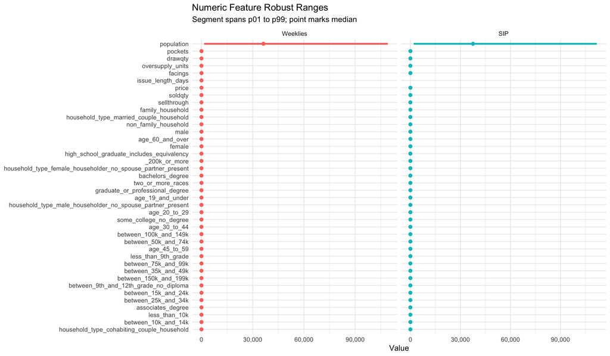

```r
range_plot <- numeric_feature_ranges[
  non_missing_count > 0 & is.finite(p01) & is.finite(p99) & p01 != p99
]

ggplot(range_plot, aes(x = p01, xend = p99, y = reorder(feature, p99), color = type)) +
  geom_segment(position = position_dodge(width = 0.7), linewidth = 1.2) +
  geom_point(aes(x = median), position = position_dodge(width = 0.7), size = 2) +
  facet_wrap(~ type, scales = "free_x") +
  scale_x_continuous(labels = comma) +
  labs(
    title = "Numeric Feature Robust Ranges",
    subtitle = "Segment spans p01 to p99; point marks median",
    x = "Value",
    y = NULL
  ) +
  theme_minimal(base_size = 11) +
  theme(legend.position = "none")
```

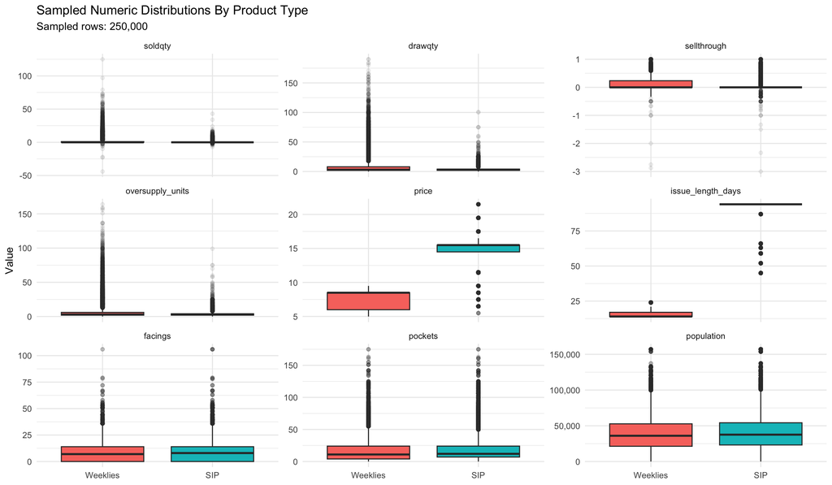

```r
sample_n <- min(params$row_sample_n, nrow(analysis))
analysis_sample <- analysis[sample(.N, sample_n)]

numeric_plot_features <- intersect(
  c("soldqty", "drawqty", "sellthrough", "oversupply_units", "price", "issue_length_days", "facings", "pockets", "population"),
  numeric_features
)

numeric_sample_long <- melt(
  analysis_sample,
  id.vars = "type",
  measure.vars = numeric_plot_features,
  variable.name = "feature",
  value.name = "value"
)
numeric_sample_long <- numeric_sample_long[!is.na(value) & is.finite(value)]

ggplot(numeric_sample_long, aes(x = type, y = value, fill = type)) +
  geom_boxplot(outlier.alpha = 0.08) +
  facet_wrap(~ feature, scales = "free_y") +
  scale_y_continuous(labels = comma) +
  labs(
    title = "Sampled Numeric Distributions By Product Type",
    subtitle = paste("Sampled rows:", comma(sample_n)),
    x = NULL,
    y = "Value"
  ) +
  theme_minimal(base_size = 11) +
  theme(legend.position = "none")
```

# 6 Missingness

```r
missingness_by_type <- rbindlist(lapply(c(categorical_features, numeric_features), function(feature) {
  x <- analysis[[feature]]
  data.table(type = analysis$type, feature = feature, feature_role = ifelse(feature %in% categorical_features, "categorical", "numeric"), missing = is.na(x) | (is.character(x) & trimws(x) == ""))[
    ,
    .(
      row_count = .N,
      missing_count = sum(missing),
      missing_rate = mean(missing)
    ),
    by = .(type, feature, feature_role)
  ]
}))

write_output(missingness_by_type, "missingness_by_type")
display_table(missingness_by_type[order(type, -missing_rate, feature)], "Missingness by feature and product type")
```

| type | feature | feature_role | row_count | missing_count | missing_rate |
| --- | --- | --- | --- | --- | --- |
| Weeklies | _200k_or_more | numeric | 5700450 | 33379 | 0.005855502635756826 |
| Weeklies | between_100k_and_149k | numeric | 5700450 | 33379 | 0.005855502635756826 |
| Weeklies | between_10k_and_14k | numeric | 5700450 | 33379 | 0.005855502635756826 |
| Weeklies | between_150k_and_199k | numeric | 5700450 | 33379 | 0.005855502635756826 |
| Weeklies | between_15k_and_24k | numeric | 5700450 | 33379 | 0.005855502635756826 |
| Weeklies | between_25k_and_34k | numeric | 5700450 | 33379 | 0.005855502635756826 |
| Weeklies | between_35k_and_49k | numeric | 5700450 | 33379 | 0.005855502635756826 |
| Weeklies | between_50k_and_74k | numeric | 5700450 | 33379 | 0.005855502635756826 |
| Weeklies | between_75k_and_99k | numeric | 5700450 | 33379 | 0.005855502635756826 |
| Weeklies | less_than_10k | numeric | 5700450 | 33379 | 0.005855502635756826 |

[output cut: 94 more lines]

## 6.1 Skimr By Product Type

This section adds standard `skimr` summaries for each product type separately so the raw missing counts are visible in one familiar table per group.

```r
skim_columns <- setdiff(names(analysis), "type")

skim_by_type <- lapply(target_types, function(current_type) {
  skim_tbl <- analysis[type == current_type, ..skim_columns] |>
    as.data.frame() |>
    skimr::skim_without_charts()

  skim_tbl <- as.data.table(skim_tbl)
  skim_tbl[, type := current_type]
  data.table::setcolorder(skim_tbl, c("type", setdiff(names(skim_tbl), "type")))
  skim_tbl
})

skim_weeklies <- skim_by_type[[which(target_types == "Weeklies")]]
skim_sip <- skim_by_type[[which(target_types == "SIP")]]
skim_combined <- rbindlist(skim_by_type, use.names = TRUE, fill = TRUE)

write_output(skim_weeklies, "skimr_weeklies")
write_output(skim_sip, "skimr_sip")
write_output(skim_combined, "skimr_by_type")

display_table(skim_weeklies, "skimr summary for Weeklies")
```

| type | skim_type | skim_variable | n_missing | complete_rate | Date.min | Date.max | Date.median | Date.n_unique | character.min | character.max | character.empty | character.n_unique | character.whitespace | logical.mean | logical.count | numeric.mean | numeric.sd | numeric.p0 | numeric.p25 | numeric.p50 | numeric.p75 | numeric.p100 |
| --- | --- | --- | --- | --- | --- | --- | --- | --- | --- | --- | --- | --- | --- | --- | --- | --- | --- | --- | --- | --- | --- | --- |
| Weeklies | Date | onsaledate | 0 | 1 | 2023-01-02 | 2024-06-24 | 2023-10-16 | 78 |  |  |  |  |  |  |  |  |  |  |  |  |  |  |
| Weeklies | Date | offsaledate | 0 | 1 | 2023-01-16 | 2024-07-11 | 2023-11-02 | 156 |  |  |  |  |  |  |  |  |  |  |  |  |  |  |
| Weeklies | character | postal_code | 0 | 1 |  |  |  |  | 6 | 6 | 0 | 7602 | 0 |  |  |  |  |  |  |  |  |  |
| Weeklies | character | store_chain | 0 | 1 |  |  |  |  | 7 | 9 | 0 | 101 | 0 |  |  |  |  |  |  |  |  |  |
| Weeklies | character | region | 0 | 1 |  |  |  |  | 4 | 19 | 0 | 16 | 0 |  |  |  |  |  |  |  |  |  |
| Weeklies | character | classoftrade | 0 | 1 |  |  |  |  | 6 | 10 | 0 | 17 | 0 |  |  |  |  |  |  |  |  |  |
| Weeklies | character | merchandised | 0 | 1 |  |  |  |  | 4 | 5 | 0 | 2 | 0 |  |  |  |  |  |  |  |  |  |
| Weeklies | character | barcode | 0 | 1 |  |  |  |  | 5 | 5 | 0 | 17 | 0 |  |  |  |  |  |  |  |  |  |
| Weeklies | character | title | 0 | 1 |  |  |  |  | 12 | 16 | 0 | 6 | 0 |  |  |  |  |  |  |  |  |  |
| Weeklies | character | segment | 0 | 1 |  |  |  |  | 6 | 13 | 0 | 2 | 0 |  |  |  |  |  |  |  |  |  |

[output cut: 49 more lines]

```r
display_table(skim_sip, "skimr summary for SIP")
```

| type | skim_type | skim_variable | n_missing | complete_rate | Date.min | Date.max | Date.median | Date.n_unique | character.min | character.max | character.empty | character.n_unique | character.whitespace | logical.mean | logical.count | numeric.mean | numeric.sd | numeric.p0 | numeric.p25 | numeric.p50 | numeric.p75 | numeric.p100 |
| --- | --- | --- | --- | --- | --- | --- | --- | --- | --- | --- | --- | --- | --- | --- | --- | --- | --- | --- | --- | --- | --- | --- |
| SIP | Date | onsaledate | 0 | 1 | 2023-01-02 | 2024-06-03 | 2023-09-11 | 75 |  |  |  |  |  |  |  |  |  |  |  |  |  |  |
| SIP | Date | offsaledate | 0 | 1 | 2023-04-06 | 2024-09-05 | 2023-12-14 | 76 |  |  |  |  |  |  |  |  |  |  |  |  |  |  |
| SIP | character | postal_code | 0 | 1 |  |  |  |  | 6 | 6 | 0 | 7628 | 0 |  |  |  |  |  |  |  |  |  |
| SIP | character | store_chain | 0 | 1 |  |  |  |  | 7 | 9 | 0 | 105 | 0 |  |  |  |  |  |  |  |  |  |
| SIP | character | region | 0 | 1 |  |  |  |  | 4 | 19 | 0 | 16 | 0 |  |  |  |  |  |  |  |  |  |
| SIP | character | classoftrade | 0 | 1 |  |  |  |  | 8 | 10 | 0 | 16 | 0 |  |  |  |  |  |  |  |  |  |
| SIP | character | merchandised | 0 | 1 |  |  |  |  | 4 | 5 | 0 | 2 | 0 |  |  |  |  |  |  |  |  |  |
| SIP | character | barcode | 0 | 1 |  |  |  |  | 4 | 5 | 0 | 250 | 0 |  |  |  |  |  |  |  |  |  |
| SIP | character | title | 0 | 1 |  |  |  |  | 9 | 9 | 0 | 1 | 0 |  |  |  |  |  |  |  |  |  |
| SIP | character | segment | 0 | 1 |  |  |  |  | 4 | 16 | 0 | 17 | 0 |  |  |  |  |  |  |  |  |  |

[output cut: 49 more lines]

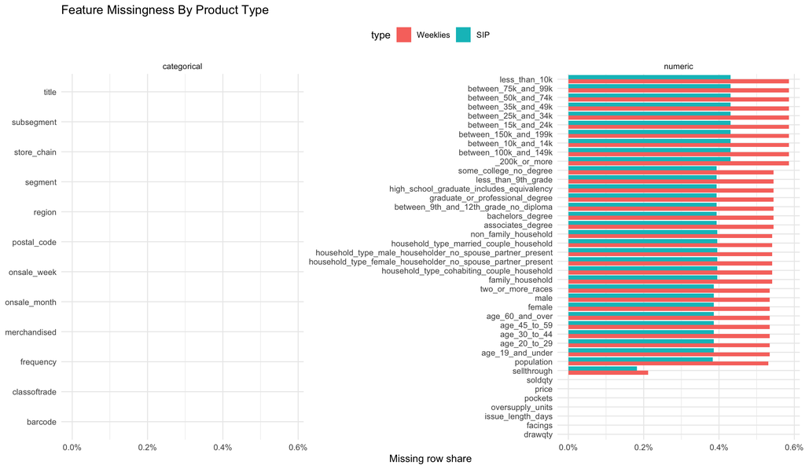

```r
ggplot(missingness_by_type, aes(x = reorder(feature, missing_rate), y = missing_rate, fill = type)) +
  geom_col(position = "dodge") +
  coord_flip() +
  facet_wrap(~ feature_role, scales = "free_y") +
  scale_y_continuous(labels = percent) +
  labs(
    title = "Feature Missingness By Product Type",
    x = NULL,
    y = "Missing row share"
  ) +
  theme_minimal(base_size = 11) +
  theme(legend.position = "top")
```

# 7 Product And Store Coverage

```r
product_coverage <- analysis[
  ,
  .(
    store_rows = .N,
    stores = uniqueN(store_id),
    soldqty_sum = sum(soldqty, na.rm = TRUE),
    drawqty_sum = sum(drawqty, na.rm = TRUE),
    aggregate_sellthrough = sum(soldqty, na.rm = TRUE) / sum(drawqty, na.rm = TRUE),
    title = first(title),
    barcode = first(barcode),
    segment = first(segment),
    subsegment = first(subsegment),
    frequency = first(frequency),
    onsaledate = first(onsaledate),
    offsaledate = first(offsaledate),
    price = first(price)
  ),
  by = .(type, product_id)
][order(type, -store_rows)]

store_coverage <- analysis[
  ,
  .(
    fact_rows = .N,
    products = uniqueN(product_id),
    titles = uniqueN(title, na.rm = TRUE),
    soldqty_sum = sum(soldqty, na.rm = TRUE),
    drawqty_sum = sum(drawqty, na.rm = TRUE),
    aggregate_sellthrough = sum(soldqty, na.rm = TRUE) / sum(drawqty, na.rm = TRUE),
    store_chain = first(store_chain),
    region = first(region),
    classoftrade = first(classoftrade),
    merchandised = first(merchandised),
    facings = first(facings),
    pockets = first(pockets),
    postal_code = first(postal_code)
  ),
  by = .(type, store_id)
][order(type, -fact_rows)]

write_output(product_coverage, "product_coverage")
write_output(store_coverage, "store_coverage")

display_table(product_coverage, "Product-level coverage and outcomes")
```

| type | product_id | store_rows | stores | soldqty_sum | drawqty_sum | aggregate_sellthrough | title | barcode | segment | subsegment | frequency | onsaledate | offsaledate | price |
| --- | --- | --- | --- | --- | --- | --- | --- | --- | --- | --- | --- | --- | --- | --- |
| Weeklies | 680061 | 8982 | 8982 | 29495 | 115060 | 0.2563445159047453 | Everyday Bloom | 67392 | WOMENS | EVERYDAY LIVING | Monthly - 12 Issues | 2024-01-22 | 2024-02-12 | 5.99 |
| Weeklies | 688222 | 8907 | 8907 | 28281 | 108447 | 0.2607817643641595 | Everyday Bloom | 64451 | WOMENS | EVERYDAY LIVING | Monthly - 12 Issues | 2024-02-12 | 2024-03-04 | 5.99 |
| Weeklies | 687821 | 8894 | 8894 | 26355 | 113270 | 0.2326741414319767 | Everyday Bloom | 64451 | WOMENS | EVERYDAY LIVING | Monthly - 12 Issues | 2024-01-01 | 2024-01-22 | 5.99 |
| Weeklies | 560823 | 8869 | 8869 | 27362 | 118652 | 0.2306071536931531 | Everyday Bloom | 64451 | WOMENS | EVERYDAY LIVING | Monthly - 12 Issues | 2023-02-20 | 2023-03-16 | 5.99 |
| Weeklies | 706544 | 8833 | 8833 | 19831 | 106605 | 0.186023169644951 | Everyday Bloom | 67392 | WOMENS | EVERYDAY LIVING | Monthly - 12 Issues | 2024-03-04 | 2024-03-21 | 5.99 |
| Weeklies | 649240 | 8405 | 8405 | 30603 | 114884 | 0.266381741582814 | Everyday Bloom | 64451 | WOMENS | EVERYDAY LIVING | Monthly - 12 Issues | 2023-08-07 | 2023-08-31 | 5.99 |
| Weeklies | 575104 | 8364 | 8364 | 24607 | 116382 | 0.2114330394734581 | Everyday Bloom | 64451 | WOMENS | EVERYDAY LIVING | Monthly - 12 Issues | 2023-05-15 | 2023-06-08 | 5.99 |
| Weeklies | 649499 | 8346 | 8346 | 25351 | 116765 | 0.2171112919111035 | Everyday Bloom | 64451 | WOMENS | EVERYDAY LIVING | Monthly - 12 Issues | 2023-06-26 | 2023-07-20 | 5.99 |
| Weeklies | 571036 | 8275 | 8275 | 31830 | 115079 | 0.2765926016041154 | Everyday Bloom | 64451 | WOMENS | EVERYDAY LIVING | Monthly - 12 Issues | 2023-04-03 | 2023-04-27 | 5.99 |
| Weeklies | 669630 | 8128 | 8128 | 26076 | 139297 | 0.1871971399240472 | Everyday Bloom | 64451 | WOMENS | EVERYDAY LIVING | Monthly - 12 Issues | 2023-11-20 | 2023-12-14 | 6.99 |

[output cut: 4990 more lines]

```r
display_table(store_coverage, "Store-level coverage and outcomes")
```

| type | store_id | fact_rows | products | titles | soldqty_sum | drawqty_sum | aggregate_sellthrough | store_chain | region | classoftrade | merchandised | facings | pockets | postal_code |
| --- | --- | --- | --- | --- | --- | --- | --- | --- | --- | --- | --- | --- | --- | --- |
| Weeklies | 697150 | 494 | 494 | 6 | 678 | 2578 | 0.2629945694336695 | Chain 4 | Łódź | DRUG CHAIN | TRUE | 10 | 10 | 74-728 |
| Weeklies | 696271 | 488 | 488 | 6 | 554 | 3018 | 0.1835652750165673 | Chain 71 | Lublin | SM CHAIN | TRUE | 22 | 28 | 93-288 |
| Weeklies | 640438 | 469 | 469 | 6 | 3555 | 14241 | 0.2496313461133347 | Chain 36 | Lublin | SM CHAIN | TRUE | 22 | 23 | 93-675 |
| Weeklies | 670591 | 451 | 451 | 6 | 422 | 3734 | 0.1130155329405463 | Chain 11 | Podlaskie | SM CHAIN | TRUE | 34 | 25 | 77-796 |
| Weeklies | 640066 | 447 | 447 | 6 | 829 | 4555 | 0.1819978046103183 | Chain 42 | Kuyavian-Pomeranian | SM CHAIN | TRUE | 15 | 22 | 70-792 |
| Weeklies | 645286 | 446 | 446 | 6 | 658 | 3633 | 0.1811175337186898 | Chain 32 | Kuyavian-Pomeranian | SM CHAIN | TRUE | 29 | 12 | 71-709 |
| Weeklies | 690501 | 445 | 445 | 6 | 1763 | 7569 | 0.2329237680010569 | Chain 44 | Lublin | NEWS INDEP | FALSE | 0 | 0 | 87-708 |
| Weeklies | 677052 | 444 | 444 | 6 | 2641 | 11110 | 0.2377137713771377 | Chain 5 | Łódź | SM CHAIN | TRUE | 15 | 45 | 75-678 |
| Weeklies | 714141 | 427 | 427 | 6 | 1793 | 7112 | 0.2521091113610799 | Chain 47 | Greater Poland | SM CHAIN | TRUE | 29 | 20 | 57-512 |
| Weeklies | 685976 | 426 | 426 | 6 | 1334 | 6906 | 0.1931653634520707 | Chain 48 | Greater Poland | SM CHAIN | TRUE | 47 | 25 | 57-390 |

[output cut: 4990 more lines]

# 8 Outputs

```r
output_manifest <- data.table(
  output_dir = output_dir,
  file = basename(list.files(output_dir, full.names = FALSE)),
  path = list.files(output_dir, full.names = TRUE)
)

display_table(output_manifest, "CSV outputs written by this notebook")
```

| output_dir | file | path |
| --- | --- | --- |
| /Users/norbert.jaworski/Documents/uni/2 rok/understandingBusiness/project/output/feature_inventory_eda/20260511_173411 | categorical_cardinality.csv | /Users/norbert.jaworski/Documents/uni/2 rok/understandingBusiness/project/output/feature_inventory_eda/20260511_173411/categorical_cardinality.csv |
| /Users/norbert.jaworski/Documents/uni/2 rok/understandingBusiness/project/output/feature_inventory_eda/20260511_173411 | categorical_value_inventory.csv | /Users/norbert.jaworski/Documents/uni/2 rok/understandingBusiness/project/output/feature_inventory_eda/20260511_173411/categorical_value_inventory.csv |
| /Users/norbert.jaworski/Documents/uni/2 rok/understandingBusiness/project/output/feature_inventory_eda/20260511_173411 | data_audit.csv | /Users/norbert.jaworski/Documents/uni/2 rok/understandingBusiness/project/output/feature_inventory_eda/20260511_173411/data_audit.csv |
| /Users/norbert.jaworski/Documents/uni/2 rok/understandingBusiness/project/output/feature_inventory_eda/20260511_173411 | feature_inventory.csv | /Users/norbert.jaworski/Documents/uni/2 rok/understandingBusiness/project/output/feature_inventory_eda/20260511_173411/feature_inventory.csv |
| /Users/norbert.jaworski/Documents/uni/2 rok/understandingBusiness/project/output/feature_inventory_eda/20260511_173411 | missingness_by_type.csv | /Users/norbert.jaworski/Documents/uni/2 rok/understandingBusiness/project/output/feature_inventory_eda/20260511_173411/missingness_by_type.csv |
| /Users/norbert.jaworski/Documents/uni/2 rok/understandingBusiness/project/output/feature_inventory_eda/20260511_173411 | numeric_feature_ranges.csv | /Users/norbert.jaworski/Documents/uni/2 rok/understandingBusiness/project/output/feature_inventory_eda/20260511_173411/numeric_feature_ranges.csv |
| /Users/norbert.jaworski/Documents/uni/2 rok/understandingBusiness/project/output/feature_inventory_eda/20260511_173411 | path_audit.csv | /Users/norbert.jaworski/Documents/uni/2 rok/understandingBusiness/project/output/feature_inventory_eda/20260511_173411/path_audit.csv |
| /Users/norbert.jaworski/Documents/uni/2 rok/understandingBusiness/project/output/feature_inventory_eda/20260511_173411 | product_coverage.csv | /Users/norbert.jaworski/Documents/uni/2 rok/understandingBusiness/project/output/feature_inventory_eda/20260511_173411/product_coverage.csv |
| /Users/norbert.jaworski/Documents/uni/2 rok/understandingBusiness/project/output/feature_inventory_eda/20260511_173411 | skimr_by_type.csv | /Users/norbert.jaworski/Documents/uni/2 rok/understandingBusiness/project/output/feature_inventory_eda/20260511_173411/skimr_by_type.csv |
| /Users/norbert.jaworski/Documents/uni/2 rok/understandingBusiness/project/output/feature_inventory_eda/20260511_173411 | skimr_sip.csv | /Users/norbert.jaworski/Documents/uni/2 rok/understandingBusiness/project/output/feature_inventory_eda/20260511_173411/skimr_sip.csv |

[output cut: 3 more lines]

```r
cat("Output directory:", output_dir, "\n")
```

```
## Output directory: /Users/norbert.jaworski/Documents/uni/2 rok/understandingBusiness/project/output/feature_inventory_eda/20260511_173411
```